# Tugas Pertemuan 2 - Metode Pemulusan Deret Waktu

Data PM2.5 (Anggota 2) - STA1341

25 August 2026

# 1 Pendahuluan

Data yang digunakan pada tugas ini adalah data **kualitas udara harian**, tepatnya variabel **PM2.5 (particulate matter 2.5 mikron, ug/m3)**, yang diambil dari dataset *Air Quality Historical*. Data asli memiliki panjang 780 periode (1 Januari 2024 - 18 Februari 2026) dan dibagi rata secara berurutan (bukan diacak, agar pola deret waktu tidak rusak) ke 5 anggota kelompok, masing-masing mendapat 156 observasi.

Bagian data yang digunakan pada laporan ini adalah bagian milik **Anggota 2**, yaitu periode **5 Juni 2024 - 7 November 2024 (156 hari)**.

Tugas ini akan menerapkan dan membandingkan empat metode pemulusan yang telah dipelajari: **Single Moving Average (SMA)**, **Double Moving Average (DMA)**, **Single Exponential Smoothing (SES)**, dan **Double Exponential Smoothing (DES)**, kemudian menentukan metode terbaik berdasarkan metrik akurasi SSE, MSE, RMSE, dan MAPE pada data uji.

# 2 Library / Packages

Package R yang digunakan pada laporan ini adalah `forecast`, `TTR`, `readxl`, dan `ggplot2`. Jika package tersebut belum ada, silakan install terlebih dahulu.

```r
# install.packages("forecast")
# install.packages("TTR")
# install.packages("readxl")
# install.packages("ggplot2")

library(forecast)
library(TTR)
library(readxl)
library(ggplot2)
```

# 3 Impor Data

Pastikan file `PM25_Anggota_2.xlsx` berada pada folder kerja (working directory) yang sama dengan file Rmd ini sebelum melakukan knit.

```r
data <- read_excel("C:/Users/oktav/Downloads/PM25_Anggota_2.xlsx", skip = 3)
colnames(data) <- c("t", "tanggal", "pm25")
data$tanggal <- as.Date(data$tanggal, format = "%Y-%m-%d")

head(data)
```

```
## # A tibble: 6 × 3
##       t tanggal     pm25
##   <dbl> <date>     <dbl>
## 1     1 2024-06-05 104.
## 2     2 2024-06-06  87.1
## 3     3 2024-06-07  72.5
## 4     4 2024-06-08  67.8
## 5     5 2024-06-09  73.4
## 6     6 2024-06-10  83.2
```

```r
tail(data)
```

```
## # A tibble: 6 × 3
##       t tanggal     pm25
##   <dbl> <date>     <dbl>
## 1   151 2024-11-02  69.8
## 2   152 2024-11-03  87.9
## 3   153 2024-11-04  89.1
## 4   154 2024-11-05  86.1
## 5   155 2024-11-06  40.8
## 6   156 2024-11-07  73.2
```

# 4 Eksplorasi Data

```r
str(data)
```

```
## tibble [156 × 3] (S3: tbl_df/tbl/data.frame)
##  $ t      : num [1:156] 1 2 3 4 5 6 7 8 9 10 ...
##  $ tanggal: Date[1:156], format: "2024-06-05" "2024-06-06" ...
##  $ pm25   : num [1:156] 104.5 87.1 72.5 67.8 73.4 ...
```

```r
dim(data)
```

```
## [1] 156   3
```

```r
summary(data$pm25)
```

```
##    Min. 1st Qu.  Median    Mean 3rd Qu.    Max.
##   26.48   61.80   70.16   70.43   80.40  108.38
```

Mengubah data menjadi objek deret waktu (`ts`) dengan fungsi `ts()`.

```r
data.ts <- ts(data$pm25)
data.ts
```

```
## Time Series:
## Start = 1
## End = 156
## Frequency = 1
##   [1] 104.4583  87.0750  72.5083  67.8042  73.4083  83.2292  66.2083  50.4083
##   [9]  51.1500  52.0667  70.9083  92.8833  88.7125  83.3250  63.7708  64.5375
##  [17]  74.1917 108.1250  84.3167  64.3333  61.1417  53.0625  41.9708  40.8500
##  [25]  43.9292  77.3875  90.9625  64.3458  87.3583  96.3000  45.9167  26.4750
##  [33]  30.7500  44.4833  46.6542  71.8542 108.3750 108.3792 101.2208  90.3750
##  [41]  76.4000  66.8333  60.0833  77.6042  69.0542  70.5875  86.0417  81.1208
##  [49]  88.4417  79.9042  81.2375  78.0042  64.0792  80.3583  83.6167  70.5250
##  [57]  62.1750  81.5542  88.4792  62.6417  72.5417 100.5917  84.4583  83.8708
##  [65]  76.8167  67.8125  69.1417  79.9250  88.5000  61.9917  58.3125  68.4250
##  [73]  78.3833  51.9833  63.2875  54.8542  57.7000  56.5917  50.0958  70.1375
##  [81]  94.3708  74.5458  62.3125  77.8000  77.9458  63.2708  76.6208  62.2417
##  [89]  60.3917  72.9208  87.6792  72.1083  59.0458  48.4542  49.1333  53.3042
##  [97]  52.0375  63.7458  46.5167  74.9625  83.3042  93.6208  88.0083  79.1583
## [105]  76.4875  58.9583  62.7750  49.5000  57.2458  71.0625  76.6875  80.5292
## [113]  73.2250  63.7208  60.9333  64.1542  76.4042  66.8083  71.3792  70.0375
## [121]  64.3875  75.0167  85.8000  65.3958  64.6708  66.7792  75.2833  70.1875
## [129]  60.1958  61.2375  57.5000  96.3000  89.7833  83.4917  75.6208  71.7708
## [137]  77.1333  42.6667  62.4708  67.2875  56.2333  64.9792  62.2750  53.8458
## [145]  79.7250  65.6042  52.4000  68.1667  66.9458  64.2833  69.7833  87.8958
## [153]  89.0917  86.1125  40.7583  73.1750
```

Membuat plot data deret waktu secara keseluruhan.

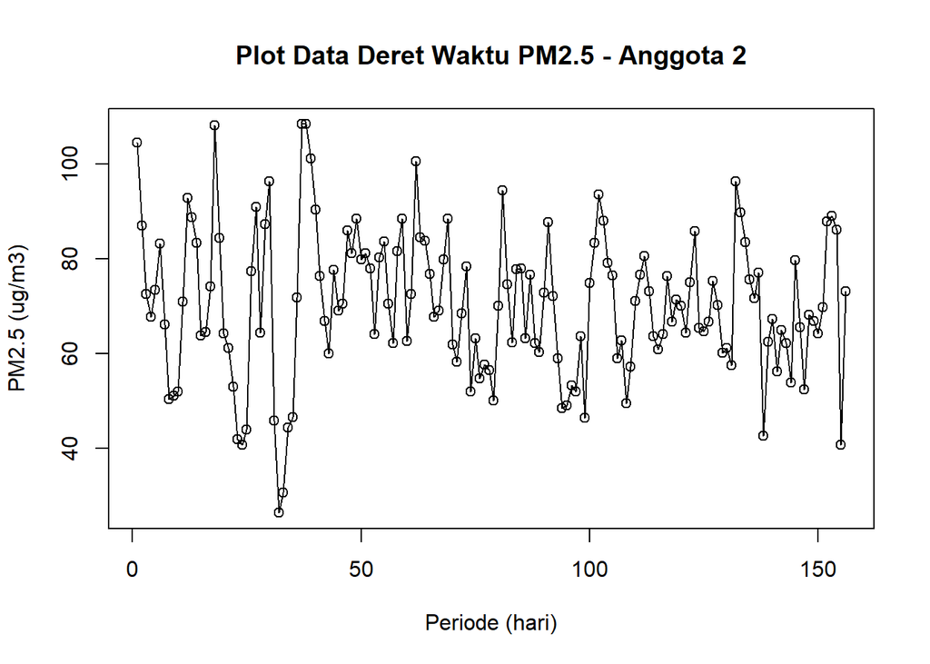

```r
ts.plot(data.ts, xlab = "Periode (hari)", ylab = "PM2.5 (ug/m3)",
        main = "Plot Data Deret Waktu PM2.5 - Anggota 2")
points(data.ts)
```

**Interpretasi awal:** dari plot terlihat data PM2.5 berfluktuasi di sekitar nilai rataan tertentu tanpa menunjukkan pola tren naik/turun yang tegas dalam jangka panjang, sehingga secara visual data cenderung **stasioner/konstan**. Pemeriksaan pola musiman mingguan (hari kerja vs akhir pekan) juga dilakukan sebagai berikut.

```r
data$hari <- weekdays(data$tanggal)
rata_hari <- aggregate(pm25 ~ hari, data = data, FUN = mean)
rata_hari[order(rata_hari$pm25), ]
```

```
##        hari     pm25
## 7 Wednesday 67.59021
## 1    Friday 68.09716
## 3  Saturday 68.43011
## 5  Thursday 70.61793
## 6   Tuesday 71.43675
## 4    Sunday 72.18977
## 2    Monday 74.76666
```

Selisih rataan PM2.5 antar hari dalam seminggu relatif kecil dibanding rataan keseluruhan data, dan tidak membentuk pola musiman yang konsisten sehingga metode **Holt-Winters (musiman)** tidak digunakan pada data ini; empat metode non-musiman (SMA, DMA, SES, DES) dinilai lebih relevan untuk dibandingkan.

# 5 Pembagian Data Latih dan Data Uji

Pembagian data latih dan data uji dilakukan dengan perbandingan **80% data latih dan 20% data uji**.

```r
n <- nrow(data)
n_train <- floor(0.8 * n)
n_test  <- n - n_train

training <- data[1:n_train, ]
testing  <- data[(n_train + 1):n, ]

train.ts <- ts(training$pm25)
test.ts  <- ts(testing$pm25)

n; n_train; n_test
```

```
## [1] 156
```

```
## [1] 124
```

```
## [1] 32
```

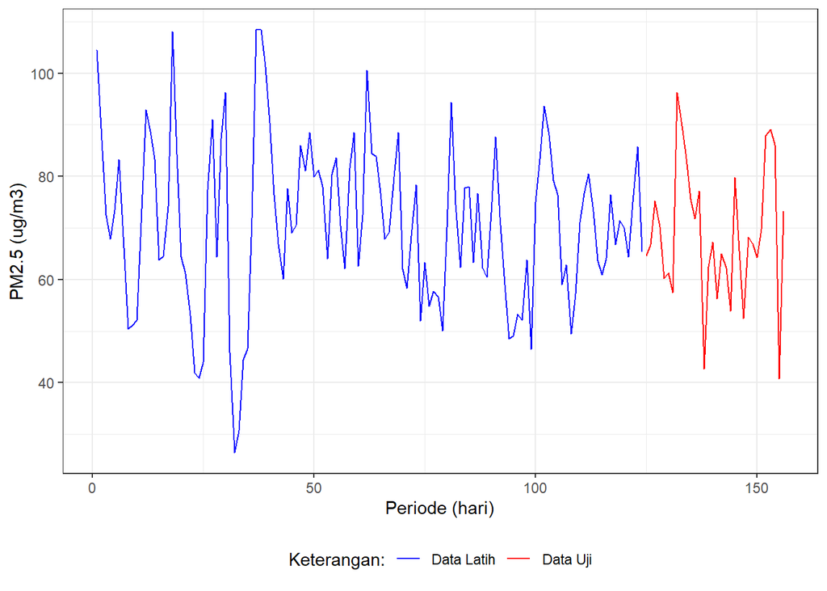

```r
ggplot() +
  geom_line(data = training, aes(x = t, y = pm25, col = "Data Latih")) +
  geom_line(data = testing, aes(x = t, y = pm25, col = "Data Uji")) +
  labs(x = "Periode (hari)", y = "PM2.5 (ug/m3)", color = "Keterangan") +
  scale_colour_manual(name = "Keterangan:",
                       breaks = c("Data Latih", "Data Uji"),
                       values = c("blue", "red")) +
  theme_bw() +
  theme(legend.position = "bottom")
```

# 6 Single Moving Average (SMA) & Double Moving Average (DMA)

## 6.1 Pemilihan Orde (m) Terbaik

Sebelum menerapkan SMA dan DMA, dicari orde `m` yang menghasilkan MSE data latih terkecil, dengan mencoba beberapa kandidat m (3 sampai 10).

```r
m_candidates <- 3:10
mse_m <- sapply(m_candidates, function(m) {
  sma_m <- SMA(train.ts, n = m)
  err <- train.ts - c(NA, sma_m[-length(sma_m)])
  mean(err[!is.na(err)]^2)
})

hasil_m <- data.frame(m = m_candidates, MSE_latih = mse_m)
hasil_m
```

```
##    m MSE_latih
## 1  3  287.0107
## 2  4  310.1260
## 3  5  333.5234
## 4  6  342.3422
## 5  7  333.2544
## 6  8  314.4147
## 7  9  295.0424
## 8 10  275.2525
```

```r
m_terbaik <- hasil_m$m[which.min(hasil_m$MSE_latih)]
m_terbaik
```

```
## [1] 10
```

Orde `m` dengan MSE data latih terkecil akan digunakan pada pemulusan SMA dan DMA berikut ini (m = 10).

## 6.2 Single Moving Average (SMA)

```r
data.sma <- SMA(train.ts, n = m_terbaik)
data.ramal.sma <- c(NA, data.sma)

# forecast n_test periode ke depan (SMA -> nilai ramalan konstan)
ramalan_sma_test <- rep(data.ramal.sma[length(data.ramal.sma)], n_test)

data.gab.sma <- cbind(
  aktual   = c(train.ts, test.ts),
  pemulusan = c(data.sma, rep(NA, n_test)),
  ramalan   = c(data.ramal.sma, ramalan_sma_test[-1])
)
tail(data.gab.sma, 10)
```

```
##         aktual pemulusan  ramalan
## [147,] 52.4000        NA 70.03167
## [148,] 68.1667        NA 70.03167
## [149,] 66.9458        NA 70.03167
## [150,] 64.2833        NA 70.03167
## [151,] 69.7833        NA 70.03167
## [152,] 87.8958        NA 70.03167
## [153,] 89.0917        NA 70.03167
## [154,] 86.1125        NA 70.03167
## [155,] 40.7583        NA 70.03167
## [156,] 73.1750        NA 70.03167
```

### 6.2.1 Akurasi SMA - Data Latih

```r
error_train.sma <- train.ts - data.ramal.sma[1:length(train.ts)]
idx <- (m_terbaik + 1):length(train.ts)

SSE_train.sma  <- sum(error_train.sma[idx]^2)
MSE_train.sma  <- mean(error_train.sma[idx]^2)
RMSE_train.sma <- sqrt(MSE_train.sma)
MAPE_train.sma <- mean(abs(error_train.sma[idx] / train.ts[idx]) * 100)

akurasi_train.sma <- data.frame(SSE = SSE_train.sma, MSE = MSE_train.sma,
                                 RMSE = RMSE_train.sma, MAPE = MAPE_train.sma)
akurasi_train.sma
```

```
##        SSE      MSE     RMSE     MAPE
## 1 31378.79 275.2525 16.59074 20.18208
```

### 6.2.2 Akurasi SMA - Data Uji

```r
error_test.sma <- test.ts - ramalan_sma_test

SSE_test.sma  <- sum(error_test.sma^2)
MSE_test.sma  <- mean(error_test.sma^2)
RMSE_test.sma <- sqrt(MSE_test.sma)
MAPE_test.sma <- mean(abs(error_test.sma / test.ts) * 100)

akurasi_test.sma <- data.frame(SSE = SSE_test.sma, MSE = MSE_test.sma,
                                RMSE = RMSE_test.sma, MAPE = MAPE_test.sma)
akurasi_test.sma
```

```
##        SSE      MSE     RMSE     MAPE
## 1 5374.037 167.9387 12.95911 16.19147
```

## 6.3 Double Moving Average (DMA)

DMA dilakukan dengan merata-ratakan hasil SMA sekali lagi (moving average dari moving average), untuk mengoreksi bias jika terdapat tren.

```r
Sp  <- SMA(train.ts, n = m_terbaik)          # M't
Spp <- SMA(Sp, n = m_terbaik)                # M''t

at <- 2 * Sp - Spp
bt <- (2 / (m_terbaik - 1)) * (Sp - Spp)

# forecast 1 periode ke depan pada data latih
ramalan_dma_train <- c(NA, at[-length(at)] + bt[-length(bt)])

data.gab.dma <- cbind(aktual = train.ts, Sp = Sp, Spp = Spp,
                       at = at, bt = bt, ramalan = ramalan_dma_train)
tail(data.gab.dma, 10)
```

```
## Time Series:
## Start = 115
## End = 124
## Frequency = 1
##      aktual       Sp      Spp       at          bt  ramalan
## 115 60.9333 65.46374 70.26145 60.66603 -1.06615733 62.36571
## 116 64.1542 65.98333 69.69178 62.27488 -0.82410044 59.59987
## 117 76.4042 67.34625 69.15103 65.54147 -0.40106289 61.45078
## 118 66.8083 69.07708 68.92583 69.22833  0.03361222 65.14040
## 119 71.3792 70.49042 68.73466 72.24618  0.39016889 69.26195
## 120 70.0375 70.38792 68.57225 72.20359  0.40348333 72.63635
## 121 64.3875 69.15792 68.35300 69.96284  0.17887178 72.60708
## 122 75.0167 68.60667 68.20954 69.00380  0.08825111 70.14171
## 123 85.8000 69.86417 68.33967 71.38867  0.33877867 69.09205
## 124 65.3958 70.03167 68.64092 71.42242  0.30905622 71.72745
```

### 6.3.1 Akurasi DMA - Data Latih

```r
error_train.dma <- train.ts - ramalan_dma_train
idx2 <- which(!is.na(error_train.dma))

SSE_train.dma  <- sum(error_train.dma[idx2]^2)
MSE_train.dma  <- mean(error_train.dma[idx2]^2)
RMSE_train.dma <- sqrt(MSE_train.dma)
MAPE_train.dma <- mean(abs(error_train.dma[idx2] / train.ts[idx2]) * 100)

akurasi_train.dma <- data.frame(SSE = SSE_train.dma, MSE = MSE_train.dma,
                                 RMSE = RMSE_train.dma, MAPE = MAPE_train.dma)
akurasi_train.dma
```

```
##        SSE      MSE     RMSE     MAPE
## 1 35215.39 335.3847 18.31351 22.01043
```

### 6.3.2 Akurasi DMA - Data Uji

Ramalan untuk h periode ke depan pada DMA menggunakan persamaan $F_{n+m} = a_n + b_n \cdot m$, dengan $a_n, b_n$ diambil dari nilai terakhir pada data latih.

```r
at_n <- at[length(at)]
bt_n <- bt[length(bt)]
m_ahead <- 1:n_test
ramalan_dma_test <- at_n + bt_n * m_ahead

error_test.dma <- test.ts - ramalan_dma_test

SSE_test.dma  <- sum(error_test.dma^2)
MSE_test.dma  <- mean(error_test.dma^2)
RMSE_test.dma <- sqrt(MSE_test.dma)
MAPE_test.dma <- mean(abs(error_test.dma / test.ts) * 100)

akurasi_test.dma <- data.frame(SSE = SSE_test.dma, MSE = MSE_test.dma,
                                RMSE = RMSE_test.dma, MAPE = MAPE_test.dma)
akurasi_test.dma
```

```
##        SSE      MSE     RMSE     MAPE
## 1 7503.033 234.4698 15.31241 20.88182
```

# 7 Single Exponential Smoothing (SES) & Double Exponential Smoothing (DES)

## 7.1 Single Exponential Smoothing (SES)

SES cocok digunakan untuk data dengan pola stasioner/konstan. Nilai parameter alpha dioptimalkan dengan `alpha = NULL` sehingga R mencari alpha yang meminimumkan SSE data latih.

```r
ses.opt <- ses(train.ts, h = n_test, alpha = NULL)
ses.opt$model
```

```
## Simple exponential smoothing
##
## Call:
## ses(y = train.ts, h = n_test, alpha = NULL)
##
##   Smoothing parameters:
##     alpha = 0.9999
##
##   Initial states:
##     l = 78.912
##
##   sigma:  14.7142
##
##      AIC     AICc      BIC
## 1268.525 1268.725 1276.986
```

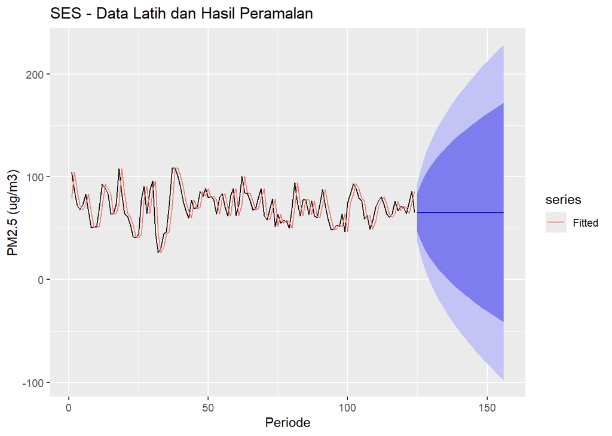

```r
autoplot(ses.opt) +
  autolayer(fitted(ses.opt), series = "Fitted") +
  ylab("PM2.5 (ug/m3)") + xlab("Periode") +
  ggtitle("SES - Data Latih dan Hasil Peramalan")
```

### 7.1.1 Akurasi SES - Data Latih

Perhitungan akurasi data latih dilakukan langsung dari nilai residual (`ses.opt$residuals` = data aktual - nilai fitted) agar tidak bergantung pada nama field internal objek `ets` yang dapat berbeda antar versi package `forecast`.

```r
resid_train.ses <- ses.opt$residuals

SSE_train.ses  <- sum(resid_train.ses^2)
MSE_train.ses  <- mean(resid_train.ses^2)
RMSE_train.ses <- sqrt(MSE_train.ses)
MAPE_train.ses <- mean(abs(resid_train.ses / train.ts) * 100)

akurasi_train.ses <- data.frame(SSE = SSE_train.ses, MSE = MSE_train.ses,
                                 RMSE = RMSE_train.ses, MAPE = MAPE_train.ses)
akurasi_train.ses
```

```
##        SSE      MSE     RMSE     MAPE
## 1 26414.07 213.0167 14.59509 17.03032
```

### 7.1.2 Akurasi SES - Data Uji

```r
ramalan_ses_test <- as.numeric(ses.opt$mean)
error_test.ses <- test.ts - ramalan_ses_test

SSE_test.ses  <- sum(error_test.ses^2)
MSE_test.ses  <- mean(error_test.ses^2)
RMSE_test.ses <- sqrt(MSE_test.ses)
MAPE_test.ses <- mean(abs(error_test.ses / test.ts) * 100)

akurasi_test.ses <- data.frame(SSE = SSE_test.ses, MSE = MSE_test.ses,
                                RMSE = RMSE_test.ses, MAPE = MAPE_test.ses)
akurasi_test.ses
```

```
##       SSE     MSE     RMSE     MAPE
## 1 5714.91 178.591 13.36379 14.99509
```

## 7.2 Double Exponential Smoothing (DES) - Metode Holt

DES (metode Holt, dua parameter) digunakan untuk memeriksa apakah memasukkan komponen tren dapat memperbaiki hasil peramalan, meskipun dari eksplorasi awal data cenderung tidak menunjukkan tren yang kuat.

```r
des.opt <- HoltWinters(train.ts, gamma = FALSE)
des.opt
```

```
## Holt-Winters exponential smoothing with trend and without seasonal component.
##
## Call:
## HoltWinters(x = train.ts, gamma = FALSE)
##
## Smoothing parameters:
##  alpha: 1
##  beta : 0.07913238
##  gamma: FALSE
##
## Coefficients:
##         [,1]
## a 65.3958000
## b -0.3866241
```

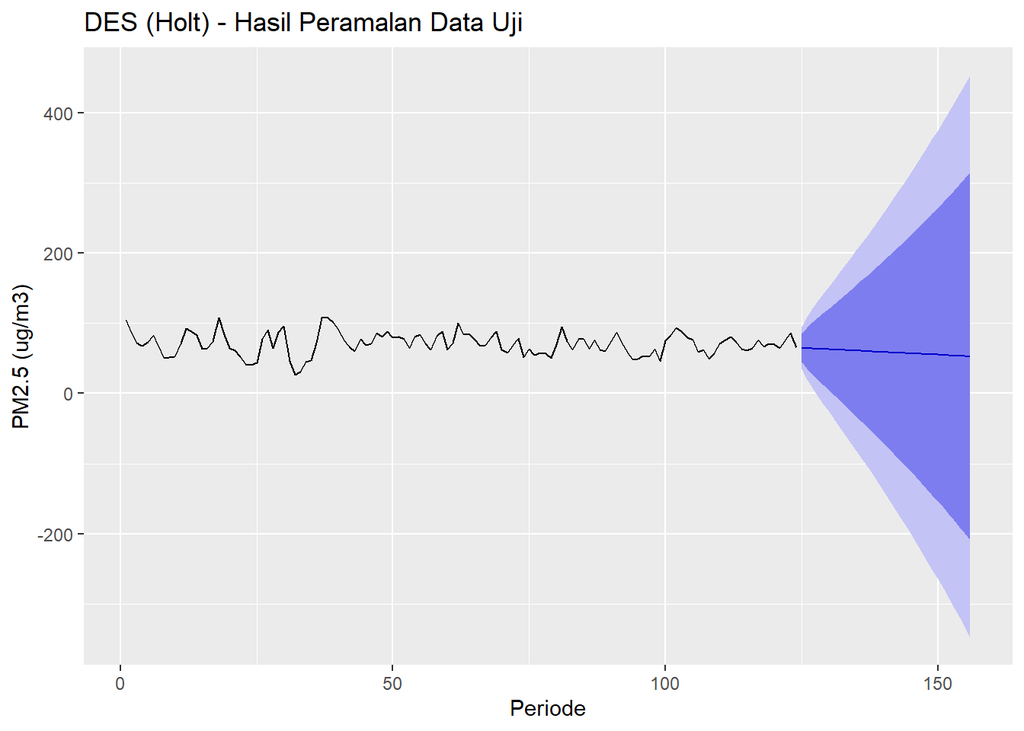

```r
ramalan.des <- forecast(des.opt, h = n_test)
autoplot(ramalan.des) + ylab("PM2.5 (ug/m3)") + xlab("Periode") +
  ggtitle("DES (Holt) - Hasil Peramalan Data Uji")
```

### 7.2.1 Akurasi DES - Data Latih

Objek `HoltWinters` menyimpan langsung nilai `SSE` (sum of squared errors) pada elemen `$SSE`. Nilai MSE dihitung dengan membagi SSE dengan banyaknya titik fitted (karena beberapa observasi awal hilang akibat inisialisasi level & tren).

```r
SSE_train.des <- des.opt$SSE
fitted.des <- fitted(des.opt)[, 1]
actual.des <- train.ts[(length(train.ts) - length(fitted.des) + 1):length(train.ts)]

MSE_train.des  <- SSE_train.des / length(fitted.des)
RMSE_train.des <- sqrt(MSE_train.des)
MAPE_train.des <- mean(abs((actual.des - fitted.des) / actual.des) * 100)

akurasi_train.des <- data.frame(SSE = SSE_train.des, MSE = MSE_train.des,
                                 RMSE = RMSE_train.des, MAPE = MAPE_train.des)
akurasi_train.des
```

```
##        SSE      MSE     RMSE     MAPE
## 1 29098.58 238.5129 15.44386 18.12265
```

### 7.2.2 Akurasi DES - Data Uji

```r
ramalan_des_test <- as.numeric(ramalan.des$mean)
error_test.des <- test.ts - ramalan_des_test

SSE_test.des  <- sum(error_test.des^2)
MSE_test.des  <- mean(error_test.des^2)
RMSE_test.des <- sqrt(MSE_test.des)
MAPE_test.des <- mean(abs(error_test.des / test.ts) * 100)

akurasi_test.des <- data.frame(SSE = SSE_test.des, MSE = MSE_test.des,
                                RMSE = RMSE_test.des, MAPE = MAPE_test.des)
akurasi_test.des
```

```
##        SSE      MSE     RMSE     MAPE
## 1 8796.957 274.9049 16.58026 17.86193
```

# 8 Perbandingan Metode & Pemilihan Model Terbaik

Perbandingan dilakukan berdasarkan metrik akurasi pada **data uji**, karena performa pada data uji mencerminkan kemampuan generalisasi model terhadap data baru yang belum “dilihat” saat pemulusan.

```r
perbandingan <- data.frame(
  Metode = c("SMA", "DMA", "SES", "DES"),
  SSE  = c(SSE_test.sma, SSE_test.dma, SSE_test.ses, SSE_test.des),
  MSE  = c(MSE_test.sma, MSE_test.dma, MSE_test.ses, MSE_test.des),
  RMSE = c(RMSE_test.sma, RMSE_test.dma, RMSE_test.ses, RMSE_test.des),
  MAPE = c(MAPE_test.sma, MAPE_test.dma, MAPE_test.ses, MAPE_test.des)
)
perbandingan[order(perbandingan$MAPE), ]
```

```
##   Metode      SSE      MSE     RMSE     MAPE
## 3    SES 5714.910 178.5910 13.36379 14.99509
## 1    SMA 5374.037 167.9387 12.95911 16.19147
## 4    DES 8796.957 274.9049 16.58026 17.86193
## 2    DMA 7503.033 234.4698 15.31241 20.88182
```

```r
metode_terbaik <- perbandingan$Metode[which.min(perbandingan$MAPE)]
metode_terbaik
```

```
## [1] "SES"
```

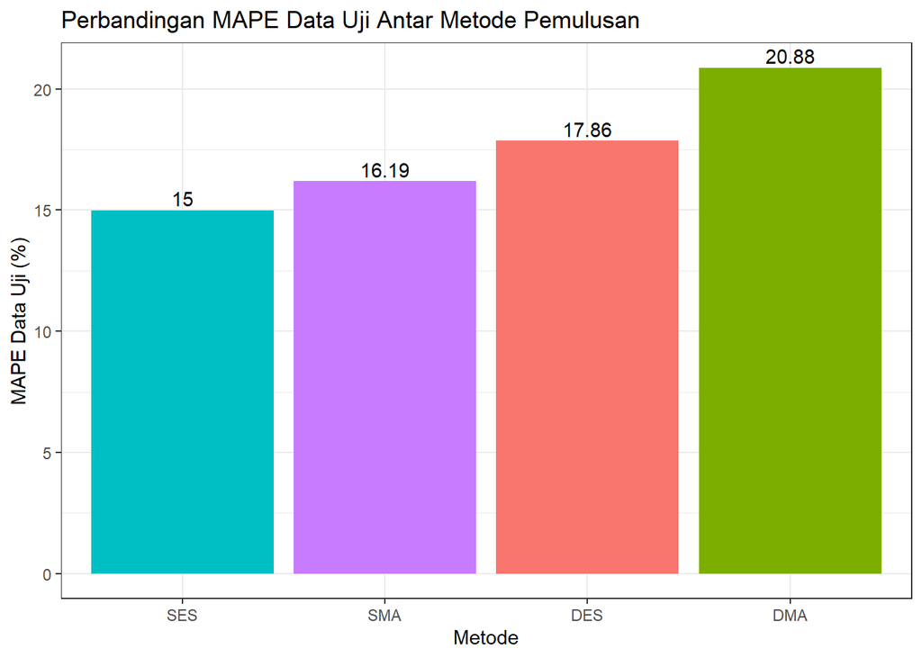

```r
ggplot(perbandingan, aes(x = reorder(Metode, MAPE), y = MAPE, fill = Metode)) +
  geom_col() +
  geom_text(aes(label = round(MAPE, 2)), vjust = -0.3) +
  labs(x = "Metode", y = "MAPE Data Uji (%)",
       title = "Perbandingan MAPE Data Uji Antar Metode Pemulusan") +
  theme_bw() + theme(legend.position = "none")
```

# 9 Kesimpulan

Berdasarkan hasil perbandingan metrik akurasi pada data uji, metode dengan nilai **MAPE terkecil** adalah **SES**, sehingga metode ini dipilih sebagai metode pemulusan terbaik untuk data PM2.5 pada bagian Anggota 2.

Beberapa hal yang mendasari hasil ini:

- Dari eksplorasi awal, data PM2.5 pada rentang 5 Juni - 7 November 2024 cenderung berfluktuasi di sekitar rataan tertentu tanpa tren jangka panjang yang tegas dan tanpa pola musiman mingguan yang konsisten, sehingga metode non-musiman (SMA, DMA, SES, DES) sudah tepat dipilih dan metode Holt-Winters musiman tidak diperlukan.
- Metode **SMA** dan **SES** dirancang untuk data dengan pola konstan/stasioner, sedangkan **DMA** dan **DES** dirancang untuk data yang mengandung tren. Karena data ini tidak menunjukkan tren yang kuat, secara teori SMA/SES diharapkan memberi hasil yang sebanding atau lebih baik dibanding DMA/DES - hal ini dapat dicek langsung pada tabel perbandingan di atas.
- Nilai MAPE SES pada data uji adalah 15%, yang menurut kriteria umum (Lewis, 1982) dapat dikategorikan sebagai akurasi **baik**.